# QRP - Criminology Analysis

Jason M. Chin & Alex O. Holcombe

17 January, 2021

Find more information about this study at https://osf.io/qvcdg/

Tables 2-5 of the manuscript can be reproduced with the STATA file at the OSF link above

The statistics in Tables 1-3 are reproduced below on both the full sample and the non-quantitative sample

Only the de-identified file was shared via Github and the Open Science Framework (OSF)

#Setup

```r
rm(list = ls())

#loads libraries for working with data
library(tidyverse)
```

```r
library(haven)
library(knitr)
library(PropCIs)

#loads the libraries that contains visual themes for the plots
library(RColorBrewer)
library(ggpattern)
knitr::opts_chunk$set(echo = TRUE,
 echo=TRUE, eval=TRUE, warning=FALSE, message=FALSE)
```

Wranglle the data by reading in the de-identified data and recoding some of it.

```r
#Grabs the de-identified data
QORP <- read_csv("data_deidentified/QORP_de-identified.csv")
#QORP <- read_csv("QORP_de-identified.csv")

#Recoding variables
##Recodes the quantitative vs other methods question as 1 (quant) or 0 (anything else) and turns it into a factor variable

QORP$Q1.1 <- ifelse(QORP$Q1.1 == "Yes", 1, ifelse(QORP$Q1.1 == "No", 0, NA))

##Recodes "have you used the practice.." from yes/no to 1/0
QORP$Q3.3 <- ifelse(QORP$Q3.3 == "Yes", 1, ifelse(QORP$Q3.3 == "No", 0, NA))
QORP$Q4.3 <- ifelse(QORP$Q4.3 == "Yes", 1, ifelse(QORP$Q4.3 == "No", 0, NA))
QORP$Q5.3 <- ifelse(QORP$Q5.3 == "Yes", 1, ifelse(QORP$Q5.3 == "No", 0, NA))
QORP$Q6.3 <- ifelse(QORP$Q6.3 == "Yes", 1, ifelse(QORP$Q6.3 == "No", 0, NA))
QORP$Q7.3 <- ifelse(QORP$Q7.3 == "Yes", 1, ifelse(QORP$Q7.3 == "No", 0, NA))
QORP$Q8.3 <- ifelse(QORP$Q8.3 == "Yes", 1, ifelse(QORP$Q8.3 == "No", 0, NA))
QORP$Q9.3 <- ifelse(QORP$Q9.3 == "Yes", 1, ifelse(QORP$Q9.3 == "No", 0, NA))
QORP$Q10.3 <- ifelse(QORP$Q10.3 == "Yes", 1, ifelse(QORP$Q10.3 == "No", 0, NA))
QORP$Q11.3 <- ifelse(QORP$Q11.3 == "Yes", 1, ifelse(QORP$Q11.3 == "No", 0, NA))
QORP$Q12.3 <- ifelse(QORP$Q12.3 == "Yes", 1, ifelse(QORP$Q12.3 == "No", 0, NA))
QORP$Q13.3 <- ifelse(QORP$Q13.3 == "Yes", 1, ifelse(QORP$Q13.3 == "No", 0, NA))
QORP$Q14.3 <- ifelse(QORP$Q14.3 == "Yes", 1, ifelse(QORP$Q14.3 == "No", 0, NA))
QORP$Q15.3 <- ifelse(QORP$Q15.3 == "Yes", 1, ifelse(QORP$Q15.3 == "No", 0, NA))
QORP$Q16.3 <- ifelse(QORP$Q16.3 == "Yes", 1, ifelse(QORP$Q16.3 == "No", 0, NA))
QORP$Q17.3 <- ifelse(QORP$Q17.3 == "Yes", 1, ifelse(QORP$Q17.3 == "No", 0, NA))

##Recodes "how often should..." variables (i.e., endorsement)

###Changes blanks into NAs
QORP$Q3.6 <- na_if(QORP$Q3.6, "")
QORP$Q4.6 <- na_if(QORP$Q4.6, "")
QORP$Q5.6 <- na_if(QORP$Q5.6, "")
QORP$Q6.5 <- na_if(QORP$Q6.5, "")
QORP$Q7.6 <- na_if(QORP$Q7.6, "")
QORP$Q8.6 <- na_if(QORP$Q8.6, "")
QORP$Q9.6 <- na_if(QORP$Q9.6, "")
QORP$Q10.6 <- na_if(QORP$Q10.6, "")
QORP$Q11.6 <- na_if(QORP$Q11.6, "")
QORP$Q12.6 <- na_if(QORP$Q12.6, "")
QORP$Q13.6 <- na_if(QORP$Q13.6, "")
QORP$Q14.6 <- na_if(QORP$Q14.6, "")
QORP$Q15.6 <- na_if(QORP$Q15.6, "")
QORP$Q16.6 <- na_if(QORP$Q16.6, "")
QORP$Q17.6 <- na_if(QORP$Q17.6, "")

#Recodes the endorse variable to numbers
QORP$Q3.6 <- recode(QORP$Q3.6, "Never" = 1, "Rarely" = 2, "Often" = 3, "Almost always" = 4)
QORP$Q4.6 <- recode(QORP$Q4.6, "Never" = 1, "Rarely" = 2, "Often" = 3, "Almost always" = 4)
QORP$Q5.6 <- recode(QORP$Q5.6, "Never" = 1, "Rarely" = 2, "Often" = 3, "Almost always" = 4)
QORP$Q6.5 <- recode(QORP$Q6.5, "Never" = 1, "Rarely" = 2, "Often" = 3, "Almost always" = 4)
QORP$Q7.6 <- recode(QORP$Q7.6, "Never" = 1, "Rarely" = 2, "Often" = 3, "Almost always" = 4)
QORP$Q8.6 <- recode(QORP$Q8.6, "Never" = 1, "Rarely" = 2, "Often" = 3, "Almost always" = 4)
QORP$Q9.6 <- recode(QORP$Q9.6, "Never" = 1, "Rarely" = 2, "Often" = 3, "Almost always" = 4)
QORP$Q10.6 <- recode(QORP$Q10.6, "Never" = 1, "Rarely" = 2, "Often" = 3, "Almost always" = 4)
QORP$Q11.6 <- recode(QORP$Q11.6, "Never" = 1, "Rarely" = 2, "Often" = 3, "Almost always" = 4)
QORP$Q12.6 <- recode(QORP$Q12.6, "Never" = 1, "Rarely" = 2, "Often" = 3, "Almost always" = 4)
QORP$Q13.6 <- recode(QORP$Q13.6, "Never" = 1, "Rarely" = 2, "Often" = 3, "Almost always" = 4)
QORP$Q14.6 <- recode(QORP$Q14.6, "Never" = 1, "Rarely" = 2, "Often" = 3, "Almost always" = 4)
QORP$Q15.6 <- recode(QORP$Q15.6, "Never" = 1, "Rarely" = 2, "Often" = 3, "Almost always" = 4)
QORP$Q16.6 <- recode(QORP$Q16.6, "Never" = 1, "Rarely" = 2, "Often" = 3, "Almost always" = 4)
QORP$Q17.6 <- recode(QORP$Q17.6, "Never" = 1, "Rarely" = 2, "Often" = 3, "Almost always" = 4)

##Recodes the grad student, ECR, mid-career, senior variable

###Changes blanks into NAs
QORP$Q18.2 <- na_if(QORP$Q18.2, "")

###Recodes these variables as factors in a sensible order
QORP$Q18.2 <- factor(QORP$Q18.2, levels = c("Graduate student", "Earlier career academic/researcher (including post-doctoral fellows)", "Mid-career academic/researcher", "Senior research academic/researcher"))

##Recodes the number of methods/stats classes variable

###Changes blanks into NAs
QORP$Q18.3 <- na_if(QORP$Q18.3, "")

###Changes "10 or more" to 10 for ease of analysis
QORP$Q18.3 <- ifelse(QORP$Q18.3 == "10 or more", 10, QORP$Q18.3)
QORP$Q18.3 <- as.integer(QORP$Q18.3)

#dplyr::renames the variables to something more understandable.AND NOTE 6.5 and 6.6 are switched

##Quant or Non-quant (Have you conducted quantitative research that involves null-hypothesis significance testing?)

QORP <-
  QORP %>% dplyr::rename(quant_researcher = Q1.1)

##As predicted (Reporting an unexpected finding or a result from exploratory analysis as having been predicted from the start)
QORP <-
  QORP %>% dplyr::rename(aspredicted_others = Q3.2, aspredicted_self_ever = Q3.3, aspredicted_self_percent = Q3.5, aspredicted_should = Q3.6)

##Omitting analyses (Reporting a set of results as the complete set of analyses when other analyses were also conducted)
QORP <-
  QORP %>% dplyr::rename(omittinganalyses_others = Q4.2, omittinganalyses_self_ever = Q4.3, omittinganalyses_self_percent = Q4.5, omittinganalyses_should = Q4.6)

##Hiding problems (Not disclosing known problems in the method and analysis, or problems with the data quality, that potentially impact conclusions)

QORP <-
  QORP %>% dplyr::rename(hidingproblems_others = Q5.2, hidingproblems_self_ever = Q5.3, hidingproblems_self_percent = Q5.5, hidingproblems_should = Q5.6)

##Filling in missing data (Filling in missing data points without identifying those data as simulated)

QORP <-
  QORP %>% dplyr::rename(fillingin_others = Q6.2, fillingin_self_ever = Q6.3, fillingin_self_percent = Q6.6, fillingin_should = Q6.5)

#Preregistering (Preregistering hypotheses and analysis plans prior to data collection)

QORP <-
  QORP %>% dplyr::rename(prereg_others = Q7.2, prereg_self_ever = Q7.3, prereg_self_percent = Q7.5, prereg_should = Q7.6)

#Open data (Sharing data you collected to a publicly accessible, online repository)

QORP <-
  QORP %>% dplyr::rename(opendata_others = Q8.2, opendata_self_ever = Q8.3, opendata_self_percent = Q8.5, opendata_should = Q8.6)

#Open code and materials (Sharing code or other research materials to a publicly accessible, online repository)

QORP <-
  QORP %>% dplyr::rename(opencode_others = Q9.2, opencode_self_ever = Q9.3, opencode_self_percent = Q9.5, opencode_should = Q9.6)

#Replication (Sought to replicate the work of other researchers by following their methods as closely as possible with no intentional changes)

QORP <-
  QORP %>% dplyr::rename(rep_others = Q10.2, rep_self_ever = Q10.3, rep_self_percent = Q10.5, rep_should = Q10.6)

#Preprints (Posted copies of your research so that it is not behind a paywall (e.g., on a publicly accessible, online preprint server))

QORP <-
  QORP %>% dplyr::rename(preprints_others = Q11.2, preprints_self_ever = Q11.3, preprints_self_percent = Q11.5, preprints_should = Q11.6)

#Biased reporting (Not reporting studies or variables that failed to reach statistical significance (e.g. p < 0.05) or some other desired statistical threshold)

QORP <-
  QORP %>% dplyr::rename(biasedreporting_others = Q12.2, biasedreporting_self_ever = Q12.3, biasedreporting_self_percent = Q12.5, biasedreporting_should = Q12.6)

#Biased covariate reporting (Not reporting covariates that failed to reach statistical significance (e.g. p < 0.05) or some other desired statistical threshold)

QORP <-
  QORP %>% dplyr::rename(biasedcov_others = Q13.2, biasedcov_self_ever = Q13.3, biasedcov_self_percent = Q13.5, biasedcov_should = Q13.6)

#Rounding down p-values (Rounding-off a p-value or other quantity to meet a pre-specified threshold (e.g., reporting p = 0.054 as p = 0.05 or p = 0.013 as p = 0.01))

QORP <-
  QORP %>% dplyr::rename(pvalround_others = Q14.2, pvalround_self_ever = Q14.3, pvalround_self_percent = Q14.5, pvalround_should = Q14.6)

#Data/outlier exclusion after peeking (Deciding to exclude data points after first checking the impact on statistical significance (e.g. p < 0.05) or some other desired statistical threshold)

QORP <-
  QORP %>% dplyr::rename(outliers_others = Q15.2, outliers_self_ever = Q15.3, outliers_self_percent = Q15.5, outliers_should = Q15.6)

#Optional stopping (Collecting more data for a study after first inspecting whether the results are statistically significant (e.g. p < 0.05))

QORP <-
  QORP %>% dplyr::rename(stopping_others = Q16.2, stopping_self_ever = Q16.3, stopping_self_percent = Q16.5, stopping_should = Q16.6)

#Analysis changing (Changing to another type of statistical analysis after the analysis initially chosen failed to reach statistical significance (e.g. p < 0.05) or some other desired statistical threshold)

QORP <-
  QORP %>% dplyr::rename(analysischanging_others = Q17.2, analysischanging_self_ever = Q17.3, analysischanging_self_percent = Q17.5, analysischanging_should = Q17.6)

#Career level (Which of the following best describes your current position) and number of methods/stats classes (How many university courses (undergraduate or graduate) on methodology or statistics have you taken?)

QORP <-
  QORP %>% dplyr::rename(career_level = Q18.2, classes = Q18.3)

#Creates the endorse or not binary variables (Participant responded that the practice should be used either rarely, often, or almost always)
QORP <-
mutate(QORP, aspredicted_endorse = ifelse(aspredicted_should > 1, 1, 0)) %>%
mutate(QORP, omittinganalyses_endorse = ifelse(omittinganalyses_should > 1, 1, 0)) %>%
mutate(QORP, hidingproblems_endorse = ifelse(hidingproblems_should > 1, 1, 0)) %>%
mutate(QORP, fillingin_endorse = ifelse(fillingin_should > 1, 1, 0)) %>%
mutate(QORP, prereg_endorse = ifelse(prereg_should > 1, 1, 0)) %>%
mutate(QORP, opendata_endorse = ifelse(opendata_should > 1, 1, 0)) %>%
mutate(QORP, opencode_endorse = ifelse(opencode_should > 1, 1, 0)) %>%
mutate(QORP, rep_endorse = ifelse(rep_should > 1, 1, 0)) %>%
mutate(QORP, preprints_endorse = ifelse(preprints_should > 1, 1, 0)) %>%
mutate(QORP, biasedreporting_endorse = ifelse(biasedreporting_should > 1, 1, 0)) %>%
mutate(QORP, biasedcov_endorse = ifelse(biasedcov_should > 1, 1, 0)) %>%
mutate(QORP, pvalround_endorse = ifelse(pvalround_should > 1, 1, 0)) %>%
mutate(QORP, outliers_endorse = ifelse(outliers_should > 1, 1, 0)) %>%
mutate(QORP, stopping_endorse = ifelse(stopping_should > 1, 1, 0)) %>%
mutate(QORP, analysischanging_endorse = ifelse(analysischanging_should > 1, 1, 0))

#Creates Quant only data set

QORP_quant <-
QORP  %>%
filter(quant_researcher == 1)

#Creates Non-Quant only data set

QORP_nonquant <-
QORP  %>%
filter(quant_researcher == 0)
```

Delete from non-quantitative sample the practices not asked about from that sample.

```r
QORP_nonquant <-
  QORP_nonquant %>% select(-contains("biasedreporting"))
QORP_nonquant <-
  QORP_nonquant %>% select(-contains("biasedcov"))
QORP_nonquant <-
  QORP_nonquant %>% select(-contains("pvalround"))
QORP_nonquant <-
  QORP_nonquant %>% select(-contains("outliers"))
QORP_nonquant <-
  QORP_nonquant %>% select(-contains("stopping"))
QORP_nonquant <-
  QORP_nonquant %>% select(-contains("analysischanging"))
```

Demographics - full sample, quantitative sample, non-quantitative sample

```r
#Descriptive Analyses - All data
##Type of research they do

###Number of quantitative researchers vs non-quantitative vs NA
QORP %>%
  group_by(quant_researcher) %>%
  summarise(n = n()) %>%
  mutate(freq = n / sum(n))
```

```
## # A tibble: 3 x 3
##   quant_researcher     n   freq
##              <dbl> <int>  <dbl>
## 1                0   456 0.296
## 2                1  1018 0.662
## 3               NA    64 0.0416
```

```r
##Career level
###Participants at each career level - ALL
career_all <- QORP %>%
  drop_na(career_level) %>%
  group_by(career_level) %>%
  summarise(n = n()) %>%
  mutate(freq = n / sum(n))

###Participants at each career level - Quant researchers only

career_quant <-
QORP %>%
  filter(quant_researcher == 1) %>%
  drop_na(career_level) %>%
  group_by(career_level) %>%
  summarise(n = n()) %>%
  mutate(freq = n / sum(n))

###Participants at each career level - Non-Quant researchers only

career_nonquant <-
QORP %>%
  filter(quant_researcher == 0) %>%
  drop_na(career_level) %>%
  group_by(career_level) %>%
  summarise(n = n()) %>%
  mutate(freq = n / sum(n))

career <- bind_rows(career_all, career_quant, career_nonquant, .id = "quant")

career$quant <- ifelse(career$quant == 1, "all", ifelse(career$quant == 2, "quant", "non-quant") )

###Rounds career level

career$freq <- round(career$freq, digits = 2)

###Participants at each career level - all vs quant vs non-quant

career
```

```
## # A tibble: 12 x 4
##    quant     career_level                                                n  freq
##    <chr>     <fct>                                                   <int> <dbl>
##  1 all       Graduate student                                           39  0.05
##  2 all       Earlier career academic/researcher (including post-doc…   189  0.23
##  3 all       Mid-career academic/researcher                            268  0.33
##  4 all       Senior research academic/researcher                       310  0.38
##  5 quant     Graduate student                                           32  0.05
##  6 quant     Earlier career academic/researcher (including post-doc…   158  0.25
##  7 quant     Mid-career academic/researcher                            199  0.32
##  8 quant     Senior research academic/researcher                       241  0.38
##  9 non-quant Graduate student                                            7  0.04
## 10 non-quant Earlier career academic/researcher (including post-doc…    31  0.18
## 11 non-quant Mid-career academic/researcher                             69  0.39
## 12 non-quant Senior research academic/researcher                        69  0.39
```

```r
write.csv(career, file = "tables/demographics_careerlevel.csv")

#Methods classes

##Frequency table

###Methods class frequency table - ALL

QORP %>%
  drop_na(classes) %>%
  group_by(classes) %>%
  summarise(n = n()) %>%
  mutate(freq = n / sum(n))
```

```
## # A tibble: 11 x 3
##    classes     n   freq
##      <int> <int>  <dbl>
##  1       0    15 0.0187
##  2       1    28 0.0349
##  3       2    55 0.0686
##  4       3    77 0.0960
##  5       4   106 0.132
##  6       5   117 0.146
##  7       6    97 0.121
##  8       7    56 0.0698
##  9       8    65 0.0810
## 10       9    17 0.0212
## 11      10   169 0.211
```

```r
###Methods class frequency table - Quant

QORP %>%
  filter(quant_researcher == 1) %>%
  drop_na(classes) %>%
  group_by(classes) %>%
  summarise(n = n()) %>%
  mutate(freq = n / sum(n))
```

```
## # A tibble: 11 x 3
##    classes     n    freq
##      <int> <int>   <dbl>
##  1       0     5 0.00797
##  2       1    10 0.0159
##  3       2    30 0.0478
##  4       3    42 0.0670
##  5       4    83 0.132
##  6       5    99 0.158
##  7       6    80 0.128
##  8       7    54 0.0861
##  9       8    58 0.0925
## 10       9    15 0.0239
## 11      10   151 0.241
```

```r
###Methods class frequency table - Non-quant

QORP %>%
  filter(quant_researcher == 0) %>%
  drop_na(classes) %>%
  group_by(classes) %>%
  summarise(n = n()) %>%
  mutate(freq = n / sum(n))
```

```
## # A tibble: 11 x 3
##    classes     n   freq
##      <int> <int>  <dbl>
##  1       0    10 0.0571
##  2       1    18 0.103
##  3       2    25 0.143
##  4       3    35 0.2
##  5       4    23 0.131
##  6       5    18 0.103
##  7       6    17 0.0971
##  8       7     2 0.0114
##  9       8     7 0.04
## 10       9     2 0.0114
## 11      10    18 0.103
```

```r
##Mean number of methods classes taken by quant vs non-quant researcher

classes_split <-
QORP %>%
  group_by(quant_researcher) %>%
  drop_na(classes) %>%
  summarise(mean.classes = mean(classes, na.rm = TRUE),
            sd.classes = sd(classes, na.rm = TRUE),
            n.classes = n()) %>%
  mutate(se.classes = sd.classes / sqrt(n.classes),
         lower.ci.classes = mean.classes - qt(1 - (0.05 / 2), n.classes - 1) * se.classes,
         upper.ci.classes = mean.classes + qt(1 - (0.05 / 2), n.classes - 1) * se.classes)

classes_all <-
QORP %>%
   drop_na(classes) %>%
  summarise(mean.classes = mean(classes, na.rm = TRUE),
            sd.classes = sd(classes, na.rm = TRUE),
            n.classes = n()) %>%
  mutate(se.classes = sd.classes / sqrt(n.classes),
         lower.ci.classes = mean.classes - qt(1 - (0.05 / 2), n.classes - 1) * se.classes,
         upper.ci.classes = mean.classes + qt(1 - (0.05 / 2), n.classes - 1) * se.classes)

classes <- bind_rows(classes_split, classes_all )

classes
```

```
## # A tibble: 3 x 7
##   quant_researcher mean.classes sd.classes n.classes se.classes lower.ci.classes
##              <dbl>        <dbl>      <dbl>     <int>      <dbl>            <dbl>
## 1                0         4.14       2.80       175      0.212             3.72
## 2                1         6.36       2.67       627      0.107             6.15
## 3               NA         5.88       2.85       802      0.101             5.68
## # … with 1 more variable: upper.ci.classes <dbl>
```

```r
write.csv(classes, file = "tables/demographics_careerlevel.csv")
```

Descriptive statistics on QRP and OSP use - Table 1, Table 2, Table 3 - Quant researchers

```r
#Descriptive Analyses - Quantitative criminologists only

##Self use at least once - for table 1, 2, and 3

selfuse_quant<-
QORP_quant %>%
select_at(vars(ends_with("self_ever"))) %>%
map_df(~ broom::tidy(t.test(.)), .id = 'var')

###Creates a variable to order this table in a consistent way and to be integrated with results from other studies

selfuse_quant <- mutate(selfuse_quant, sorter = c(8,4,9,10,11,12,13,14,15,1,3,5,7,2,6))
selfuse_quant <- arrange(selfuse_quant, sorter)

###Converts estimates into %s and rounds them
selfuse_quant$estimate <- selfuse_quant$estimate*100
selfuse_quant$estimate <- round(selfuse_quant$estimate, digits = 0)

###Creates the sample size variable with () around it for tables in the manuscript

selfuse_quant$parameter <- selfuse_quant$parameter + 1 #this is because the output has degrees of freedom
selfuse_quant$n <- paste("(", selfuse_quant$parameter, sep = "")
selfuse_quant$n <- paste(selfuse_quant$n, ")", sep = "")
selfuse_quant$estimate_n <- paste(selfuse_quant$estimate, sep = " ", selfuse_quant$n)

###Provides prettier row names

selfuse_quant$var <- sub("_self_ever", "", selfuse_quant$var)

###Provides proper practice names

selfuse_quant$var <- sub("prereg", "Preregister study", selfuse_quant$var)
selfuse_quant$var <- sub("opendata", "Share data", selfuse_quant$var)
selfuse_quant$var <- sub("opencode", "Share code", selfuse_quant$var)
selfuse_quant$var <- sub("rep", "Attempt replication", selfuse_quant$var)
selfuse_quant$var <- sub("pAttempt replicationrints", "Post article publicly", selfuse_quant$var)

selfuse_quant$var <- sub("biasedAttempt replicationorting", "Omit non-significant studies or variables", selfuse_quant$var)
selfuse_quant$var <- sub("stopping", "Sample selectively", selfuse_quant$var)
selfuse_quant$var <- sub("biasedcov", "Drop covariates selectively", selfuse_quant$var)
selfuse_quant$var <- sub("omittinganalyses", "Underreport results", selfuse_quant$var)
selfuse_quant$var <- sub("pvalround", "Round p-values", selfuse_quant$var)
selfuse_quant$var <- sub("analysischanging", "Switch analysis selectively", selfuse_quant$var)
selfuse_quant$var <- sub("outliers", "Exclude data selectively", selfuse_quant$var)
selfuse_quant$var <- sub("aspredicted", "HARK", selfuse_quant$var)
selfuse_quant$var <- sub("hidingproblems", "Hide problems", selfuse_quant$var)
selfuse_quant$var <- sub("fillingin", "Hide imputation", selfuse_quant$var)

selfuse_quant
```

```
## # A tibble: 15 x 12
##    var   estimate statistic   p.value parameter conf.low conf.high method
##    <chr>    <dbl>     <dbl>     <dbl>     <dbl>    <dbl>     <dbl> <chr>
##  1 Omit…       43     22.8  6.86e- 86       681   0.396     0.470  One S…
##  2 Samp…       15     11.0  4.73e- 26       680   0.124     0.178  One S…
##  3 Drop…       32     17.6  2.99e- 57       670   0.281     0.352  One S…
##  4 Unde…       53     27.8  6.00e-114       677   0.496     0.571  One S…
##  5 Roun…       27     15.8  2.44e- 48       692   0.233     0.299  One S…
##  6 Swit…       39     20.7  4.18e- 74       681   0.350     0.423  One S…
##  7 Excl…       24     14.5  1.72e- 41       679   0.204     0.268  One S…
##  8 HARK        29     16.7  1.24e- 52       686   0.255     0.323  One S…
##  9 Hide…       10      8.75 1.66e- 17       696   0.0769    0.121  One S…
## 10 Hide…        7      7.10 3.16e- 12       683   0.0498    0.0878 One S…
## 11 Prer…       45     23.7  5.24e- 91       680   0.415     0.490  One S…
## 12 Shar…       43     22.9  1.06e- 86       689   0.395     0.470  One S…
## 13 Shar…       43     22.9  1.42e- 86       683   0.398     0.472  One S…
## 14 Atte…       40     21.6  2.88e- 79       688   0.367     0.441  One S…
## 15 Post…       68     38.3  6.23e-172       680   0.649     0.719  One S…
## # … with 4 more variables: alternative <chr>, sorter <dbl>, n <chr>,
## #   estimate_n <chr>
```

```r
write.csv(selfuse_quant, file = "tables/selfuse_quant.csv")

##Self use percent - for table 2 and 3

selfusepercent_quant <-
QORP %>%
filter(quant_researcher == 1) %>%
select_at(vars(ends_with("self_percent"))) %>%
map_df(~ broom::tidy(t.test(.)), .id = 'var')

###Creates a variable to order this table in a consistent way and to be integrated with results from other studies

selfusepercent_quant <- mutate(selfusepercent_quant, sorter = c(8,4,9,10,11,12,13,14,15,1,3,5,7,2,6))
selfusepercent_quant <- arrange(selfusepercent_quant, sorter)

###Rounds

selfusepercent_quant$estimate <- round(selfusepercent_quant$estimate, digits = 0)

###Creates the sample size variable with () around it for tables in the manuscript

selfusepercent_quant$parameter <- selfusepercent_quant$parameter + 1 #this is because the output has degrees of freedom
selfusepercent_quant$n <- paste("(", selfusepercent_quant$parameter, sep = "")
selfusepercent_quant$n <- paste(selfusepercent_quant$n, ")", sep = "")
selfusepercent_quant$estimate_n <- paste(selfusepercent_quant$estimate, sep = " ", selfusepercent_quant$n)

###Provides prettier row names

selfusepercent_quant$var <- sub("_self_percent", "", selfusepercent_quant$var)

###Provides proper practice names

selfusepercent_quant$var <- sub("prereg", "Preregister study", selfusepercent_quant$var)
selfusepercent_quant$var <- sub("opendata", "Share data", selfusepercent_quant$var)
selfusepercent_quant$var <- sub("opencode", "Share code", selfusepercent_quant$var)
selfusepercent_quant$var <- sub("rep", "Attempt replication", selfusepercent_quant$var)
selfusepercent_quant$var <- sub("pAttempt replicationrints", "Post article publicly", selfusepercent_quant$var)

selfusepercent_quant$var <- sub("biasedAttempt replicationorting", "Omit non-significant studies or variables", selfusepercent_quant$var)
selfusepercent_quant$var <- sub("stopping", "Sample selectively", selfusepercent_quant$var)
selfusepercent_quant$var <- sub("biasedcov", "Drop covariates selectively", selfusepercent_quant$var)
selfusepercent_quant$var <- sub("omittinganalyses", "Underreport results", selfusepercent_quant$var)
selfusepercent_quant$var <- sub("pvalround", "Round p-values", selfusepercent_quant$var)
selfusepercent_quant$var <- sub("analysischanging", "Switch analysis selectively", selfusepercent_quant$var)
selfusepercent_quant$var <- sub("outliers", "Exclude data selectively", selfusepercent_quant$var)
selfusepercent_quant$var <- sub("aspredicted", "HARK", selfusepercent_quant$var)
selfusepercent_quant$var <- sub("hidingproblems", "Hide problems", selfusepercent_quant$var)
selfusepercent_quant$var <- sub("fillingin", "Hide imputation", selfusepercent_quant$var)

selfusepercent_quant
```

```
## # A tibble: 15 x 12
##    var   estimate statistic   p.value parameter conf.low conf.high method
##    <chr>    <dbl>     <dbl>     <dbl>     <dbl>    <dbl>     <dbl> <chr>
##  1 Omit…       34     19.8  5.15e- 55       278     30.7      37.5 One S…
##  2 Samp…       29     10.1  7.15e- 17        99     23.1      34.4 One S…
##  3 Drop…       39     17.3  7.54e- 42       206     34.9      43.9 One S…
##  4 Unde…       47     26.2  6.59e- 84       346     43.7      50.8 One S…
##  5 Roun…       46     16.7  4.32e- 38       176     40.4      51.2 One S…
##  6 Swit…       29     17.3  9.53e- 45       252     25.4      31.9 One S…
##  7 Excl…       34     13.5  1.09e- 27       149     29.0      38.9 One S…
##  8 HARK        36     15.7  9.17e- 36       186     31.1      40.1 One S…
##  9 Hide…       31      7.49 2.54e- 10        65     22.5      38.9 One S…
## 10 Hide…       34      6.93 1.30e-  8        46     24.1      43.9 One S…
## 11 Prer…       50     23.6  5.50e- 70       296     45.5      53.8 One S…
## 12 Shar…       34     20.6  1.43e- 58       289     30.7      37.1 One S…
## 13 Shar…       32     19.8  2.63e- 55       284     28.8      35.1 One S…
## 14 Atte…       21     15.2  5.17e- 38       266     18.2      23.6 One S…
## 15 Post…       59     39.5  1.85e-147       446     55.9      61.7 One S…
## # … with 4 more variables: alternative <chr>, sorter <dbl>, n <chr>,
## #   estimate_n <chr>
```

```r
write.csv(selfusepercent_quant, file = "tables/selfusepercent_quant.csv")
```

#Descriptive statistics on QRP and OSP use - Table 1, Table 2, Table 3 - All researchers

```r
#Descriptive Analyses

##Self use at least once - for table 1, 2, and 3

selfuse_quant<-
QORP %>%
select_at(vars(ends_with("self_ever"))) %>%
map_df(~ broom::tidy(t.test(.)), .id = 'var')

###Creates a variable to order this table in a consistent way and to be integrated with results from other studies

selfuse_quant <- mutate(selfuse_quant, sorter = c(8,4,9,10,11,12,13,14,15,1,3,5,7,2,6))
selfuse_quant <- arrange(selfuse_quant, sorter)

###Converts estimates into %s and rounds them
selfuse_quant$estimate <- selfuse_quant$estimate*100
selfuse_quant$estimate <- round(selfuse_quant$estimate, digits = 0)

###Creates the sample size variable with () around it for tables in the manuscript

selfuse_quant$parameter <- selfuse_quant$parameter + 1 #this is because the output has degrees of freedom
selfuse_quant$n <- paste("(", selfuse_quant$parameter, sep = "")
selfuse_quant$n <- paste(selfuse_quant$n, ")", sep = "")
selfuse_quant$estimate_n <- paste(selfuse_quant$estimate, sep = " ", selfuse_quant$n)

###Provides prettier row names

selfuse_quant$var <- sub("_self_ever", "", selfuse_quant$var)

###Provides proper practice names

selfuse_quant$var <- sub("prereg", "Preregister study", selfuse_quant$var)
selfuse_quant$var <- sub("opendata", "Share data", selfuse_quant$var)
selfuse_quant$var <- sub("opencode", "Share code", selfuse_quant$var)
selfuse_quant$var <- sub("rep", "Attempt replication", selfuse_quant$var)
selfuse_quant$var <- sub("pAttempt replicationrints", "Post article publicly", selfuse_quant$var)

selfuse_quant$var <- sub("biasedAttempt replicationorting", "Omit non-significant studies or variables", selfuse_quant$var)
selfuse_quant$var <- sub("stopping", "Sample selectively", selfuse_quant$var)
selfuse_quant$var <- sub("biasedcov", "Drop covariates selectively", selfuse_quant$var)
selfuse_quant$var <- sub("omittinganalyses", "Underreport results", selfuse_quant$var)
selfuse_quant$var <- sub("pvalround", "Round p-values", selfuse_quant$var)
selfuse_quant$var <- sub("analysischanging", "Switch analysis selectively", selfuse_quant$var)
selfuse_quant$var <- sub("outliers", "Exclude data selectively", selfuse_quant$var)
selfuse_quant$var <- sub("aspredicted", "HARK", selfuse_quant$var)
selfuse_quant$var <- sub("hidingproblems", "Hide problems", selfuse_quant$var)
selfuse_quant$var <- sub("fillingin", "Hide imputation", selfuse_quant$var)

selfuse_all <- selfuse_quant

selfuse_all
```

```
## # A tibble: 15 x 12
##    var   estimate statistic   p.value parameter conf.low conf.high method
##    <chr>    <dbl>     <dbl>     <dbl>     <dbl>    <dbl>     <dbl> <chr>
##  1 Omit…       43     22.8  6.86e- 86       681   0.396     0.470  One S…
##  2 Samp…       15     11.0  4.73e- 26       680   0.124     0.178  One S…
##  3 Drop…       32     17.6  2.99e- 57       670   0.281     0.352  One S…
##  4 Unde…       46     27.4  8.86e-120       873   0.430     0.496  One S…
##  5 Roun…       27     15.8  2.44e- 48       692   0.233     0.299  One S…
##  6 Swit…       39     20.7  4.18e- 74       681   0.350     0.423  One S…
##  7 Excl…       24     14.5  1.72e- 41       679   0.204     0.268  One S…
##  8 HARK        27     18.3  7.96e- 64       894   0.244     0.302  One S…
##  9 Hide…       10      9.80 1.24e- 21       912   0.0763    0.114  One S…
## 10 Hide…        6      7.50 1.51e- 13       885   0.0442    0.0755 One S…
## 11 Prer…       40     24.3  1.61e-100       885   0.369     0.433  One S…
## 12 Shar…       39     24.5  2.81e-102       919   0.363     0.427  One S…
## 13 Shar…       38     23.5  2.88e- 95       893   0.350     0.414  One S…
## 14 Atte…       34     21.7  5.93e- 84       895   0.313     0.375  One S…
## 15 Post…       69     45.0  2.93e-232       900   0.662     0.722  One S…
## # … with 4 more variables: alternative <chr>, sorter <dbl>, n <chr>,
## #   estimate_n <chr>
```

```r
write.csv(selfuse_all, file = "tables/selfuse_all.csv")

##Self use percent - for table 2 and 3

selfusepercent_quant <-
QORP %>%
select_at(vars(ends_with("self_percent"))) %>%
map_df(~ broom::tidy(t.test(.)), .id = 'var')

###Creates a variable to order this table in a consistent way and to be integrated with results from other studies

selfusepercent_quant <- mutate(selfusepercent_quant, sorter = c(8,4,9,10,11,12,13,14,15,1,3,5,7,2,6))
selfusepercent_quant <- arrange(selfusepercent_quant, sorter)

###Rounds

selfusepercent_quant$estimate <- round(selfusepercent_quant$estimate, digits = 0)

###Creates the sample size variable with () around it for tables in the manuscript

selfusepercent_quant$parameter <- selfusepercent_quant$parameter + 1 #this is because the output has degrees of freedom
selfusepercent_quant$n <- paste("(", selfusepercent_quant$parameter, sep = "")
selfusepercent_quant$n <- paste(selfusepercent_quant$n, ")", sep = "")
selfusepercent_quant$estimate_n <- paste(selfusepercent_quant$estimate, sep = " ", selfusepercent_quant$n)

###Provides prettier row names

selfusepercent_quant$var <- sub("_self_percent", "", selfusepercent_quant$var)

###Provides proper practice names

selfusepercent_quant$var <- sub("prereg", "Preregister study", selfusepercent_quant$var)
selfusepercent_quant$var <- sub("opendata", "Share data", selfusepercent_quant$var)
selfusepercent_quant$var <- sub("opencode", "Share code", selfusepercent_quant$var)
selfusepercent_quant$var <- sub("rep", "Attempt replication", selfusepercent_quant$var)
selfusepercent_quant$var <- sub("pAttempt replicationrints", "Post article publicly", selfusepercent_quant$var)

selfusepercent_quant$var <- sub("biasedAttempt replicationorting", "Omit non-significant studies or variables", selfusepercent_quant$var)
selfusepercent_quant$var <- sub("stopping", "Sample selectively", selfusepercent_quant$var)
selfusepercent_quant$var <- sub("biasedcov", "Drop covariates selectively", selfusepercent_quant$var)
selfusepercent_quant$var <- sub("omittinganalyses", "Underreport results", selfusepercent_quant$var)
selfusepercent_quant$var <- sub("pvalround", "Round p-values", selfusepercent_quant$var)
selfusepercent_quant$var <- sub("analysischanging", "Switch analysis selectively", selfusepercent_quant$var)
selfusepercent_quant$var <- sub("outliers", "Exclude data selectively", selfusepercent_quant$var)
selfusepercent_quant$var <- sub("aspredicted", "HARK", selfusepercent_quant$var)
selfusepercent_quant$var <- sub("hidingproblems", "Hide problems", selfusepercent_quant$var)
selfusepercent_quant$var <- sub("fillingin", "Hide imputation", selfusepercent_quant$var)

selfusepercent_all <- selfusepercent_quant

selfusepercent_all
```

```
## # A tibble: 15 x 12
##    var   estimate statistic   p.value parameter conf.low conf.high method
##    <chr>    <dbl>     <dbl>     <dbl>     <dbl>    <dbl>     <dbl> <chr>
##  1 Omit…       34     19.8  5.15e- 55       278     30.7      37.5 One S…
##  2 Samp…       29     10.1  7.15e- 17        99     23.1      34.4 One S…
##  3 Drop…       39     17.3  7.54e- 42       206     34.9      43.9 One S…
##  4 Unde…       47     27.7  8.34e- 94       387     43.9      50.6 One S…
##  5 Roun…       46     16.7  4.32e- 38       176     40.4      51.2 One S…
##  6 Swit…       29     17.3  9.53e- 45       252     25.4      31.9 One S…
##  7 Excl…       34     13.5  1.09e- 27       149     29.0      38.9 One S…
##  8 HARK        37     17.5  6.99e- 44       227     33.2      41.6 One S…
##  9 Hide…       33      8.42 1.23e- 12        81     24.8      40.2 One S…
## 10 Hide…       31      6.77 1.27e-  8        52     21.6      39.8 One S…
## 11 Prer…       50     25.7  1.51e- 81       341     46.1      53.8 One S…
## 12 Shar…       35     22.5  8.73e- 70       347     31.9      38.0 One S…
## 13 Shar…       33     21.0  2.98e- 62       321     29.5      35.6 One S…
## 14 Atte…       22     15.9  2.18e- 41       296     19.2      24.6 One S…
## 15 Post…       59     45.6  1.12e-195       593     56.5      61.6 One S…
## # … with 4 more variables: alternative <chr>, sorter <dbl>, n <chr>,
## #   estimate_n <chr>
```

```r
write.csv(selfusepercent_all, file = "tables/selfusepercent_all.csv")
```

#Descriptive statistics on QRP and OSP use - Table 1, Table 2, Table 3 - Non quant

```r
#Descriptive Analyses

##Self use at least once - for table 1, 2, and 3

selfuse_quant<-
QORP_nonquant %>%
select_at(vars(ends_with("self_ever"))) %>%
map_df(~ broom::tidy(t.test(.)), .id = 'var')

###Creates a variable to order this table in a consistent way and to be integrated with results from other studies

selfuse_quant <- mutate(selfuse_quant, sorter = c(2,1,3,4,5,6,7,8,9))
selfuse_quant <- arrange(selfuse_quant, sorter)

###Converts estimates into %s and rounds them
selfuse_quant$estimate <- selfuse_quant$estimate*100
selfuse_quant$estimate <- round(selfuse_quant$estimate, digits = 0)

###Creates the sample size variable with () around it for tables in the manuscript

selfuse_quant$parameter <- selfuse_quant$parameter + 1 #this is because the output has degrees of freedom
selfuse_quant$n <- paste("(", selfuse_quant$parameter, sep = "")
selfuse_quant$n <- paste(selfuse_quant$n, ")", sep = "")
selfuse_quant$estimate_n <- paste(selfuse_quant$estimate, sep = " ", selfuse_quant$n)

###Provides prettier row names

selfuse_quant$var <- sub("_self_ever", "", selfuse_quant$var)

###Provides proper practice names

selfuse_quant$var <- sub("prereg", "Preregister study", selfuse_quant$var)
selfuse_quant$var <- sub("opendata", "Share data", selfuse_quant$var)
selfuse_quant$var <- sub("opencode", "Share code", selfuse_quant$var)
selfuse_quant$var <- sub("rep", "Attempt replication", selfuse_quant$var)
selfuse_quant$var <- sub("pAttempt replicationrints", "Post article publicly", selfuse_quant$var)


selfuse_quant$var <- sub("omittinganalyses", "Underreport results", selfuse_quant$var)
selfuse_quant$var <- sub("aspredicted", "HARK", selfuse_quant$var)
selfuse_quant$var <- sub("hidingproblems", "Hide problems", selfuse_quant$var)
selfuse_quant$var <- sub("fillingin", "Hide imputation", selfuse_quant$var)

selfuse_nonquant <- selfuse_quant

selfuse_nonquant
```

```
## # A tibble: 9 x 12
##   var   estimate statistic  p.value parameter conf.low conf.high method
##   <chr>    <dbl>     <dbl>    <dbl>     <dbl>    <dbl>     <dbl> <chr>
## 1 Unde…       22      7.40 3.90e-12       196  0.161      0.278  One S…
## 2 HARK        22      7.67 6.75e-13       208  0.164      0.278  One S…
## 3 Hide…        8      4.42 1.56e- 5       216  0.0462     0.120  One S…
## 4 Hide…        3      2.48 1.39e- 2       202  0.00609    0.0533 One S…
## 5 Prer…       23      7.79 3.34e-13       205  0.171      0.287  One S…
## 6 Shar…       28      9.50 2.99e-18       230  0.224      0.341  One S…
## 7 Shar…       21      7.44 2.53e-12       210  0.154      0.265  One S…
## 8 Atte…       14      5.91 1.41e- 8       207  0.0966     0.193  One S…
## 9 Post…       72     23.6  3.75e-62       220  0.658      0.778  One S…
## # … with 4 more variables: alternative <chr>, sorter <dbl>, n <chr>,
## #   estimate_n <chr>
```

```r
write.csv(selfuse_nonquant, file = "tables/selfuse_nonquant.csv")

##Self use percent - for table 2 and 3

selfusepercent_quant <-
QORP_nonquant %>%
select_at(vars(ends_with("self_percent"))) %>%
map_df(~ broom::tidy(t.test(.)), .id = 'var')

###Creates a variable to order this table in a consistent way and to be integrated with results from other studies

selfusepercent_quant <- mutate(selfusepercent_quant, sorter = c(2,1,3,4,5,6,7,8,9))
selfusepercent_quant <- arrange(selfusepercent_quant, sorter)

###Rounds

selfusepercent_quant$estimate <- round(selfusepercent_quant$estimate, digits = 0)

###Creates the sample size variable with () around it for tables in the manuscript

selfusepercent_quant$parameter <- selfusepercent_quant$parameter + 1 #this is because the output has degrees of freedom
selfusepercent_quant$n <- paste("(", selfusepercent_quant$parameter, sep = "")
selfusepercent_quant$n <- paste(selfusepercent_quant$n, ")", sep = "")
selfusepercent_quant$estimate_n <- paste(selfusepercent_quant$estimate, sep = " ", selfusepercent_quant$n)

###Provides prettier row names

selfusepercent_quant$var <- sub("_self_percent", "", selfusepercent_quant$var)

###Provides proper practice names

selfuse_quant$var <- sub("prereg", "Preregister study", selfuse_quant$var)
selfuse_quant$var <- sub("opendata", "Share data", selfuse_quant$var)
selfuse_quant$var <- sub("opencode", "Share code", selfuse_quant$var)
selfuse_quant$var <- sub("rep", "Attempt replication", selfuse_quant$var)
selfuse_quant$var <- sub("pAttempt replicationrints", "Post article publicly", selfuse_quant$var)

selfuse_quant$var <- sub("omittinganalyses", "Underreport results", selfuse_quant$var)
selfuse_quant$var <- sub("aspredicted", "HARK", selfuse_quant$var)
selfuse_quant$var <- sub("hidingproblems", "Hide problems", selfuse_quant$var)
selfuse_quant$var <- sub("fillingin", "Hide imputation", selfuse_quant$var)

selfusepercent_nonquant <- selfusepercent_quant

selfusepercent_nonquant
```

```
## # A tibble: 9 x 12
##   var   estimate statistic  p.value parameter conf.low conf.high method
##   <chr>    <dbl>     <dbl>    <dbl>     <dbl>    <dbl>     <dbl> <chr>
## 1 omit…       47      9.02 3.50e-11        41    36.5       57.7 One S…
## 2 aspr…       46      7.97 8.68e-10        41    34.0       57.1 One S…
## 3 hidi…       40      3.85 1.58e- 3        16    17.8       62.0 One S…
## 4 fill…        5      1.60 1.69e- 1         6    -3.21      13.9 One S…
## 5 prer…       52     10.0  6.43e-13        45    41.5       62.4 One S…
## 6 open…       40      9.29 5.27e-13        58    31.5       48.8 One S…
## 7 open…       38      7.19 1.84e- 8        37    27.0       48.1 One S…
## 8 rep         31      5.16 1.64e- 5        30    18.5       42.9 One S…
## 9 prep…       60     22.7  1.06e-49       147    54.5       64.9 One S…
## # … with 4 more variables: alternative <chr>, sorter <dbl>, n <chr>,
## #   estimate_n <chr>
```

```r
write.csv(selfusepercent_nonquant, file = "tables/selfusepercent_nonquant.csv")
```

Descriptive statistics on QRP and ORP Support - Quantitative researchers

```r
##Support - on the mean 1-4 measure

endorse_quant <-
QORP_quant %>%
select_at(vars(ends_with("should"))) %>%
map_df(~ broom::tidy(t.test(.)), .id = 'var')
endorse_quant
```

```
## # A tibble: 15 x 9
##    var   estimate statistic   p.value parameter conf.low conf.high method
##    <chr>    <dbl>     <dbl>     <dbl>     <dbl>    <dbl>     <dbl> <chr>
##  1 aspr…     1.70      48.2 4.39e-220       671     1.63      1.77 One S…
##  2 omit…     2.11      62.2 6.94e-278       658     2.04      2.18 One S…
##  3 hidi…     1.44      42.6 1.81e-194       684     1.37      1.50 One S…
##  4 fill…     1.25      55.6 2.50e-253       671     1.20      1.29 One S…
##  5 prer…     2.96      98.6 0.              664     2.90      3.02 One S…
##  6 open…     2.99     117.  0.              674     2.94      3.04 One S…
##  7 open…     3.06     112.  0.              663     3.00      3.11 One S…
##  8 rep_…     2.84     144.  0.              667     2.80      2.88 One S…
##  9 prep…     3.13      98.9 0.              654     3.06      3.19 One S…
## 10 bias…     1.94      58.1 1.73e-260       654     1.87      2.00 One S…
## 11 bias…     1.87      56.3 9.63e-254       658     1.80      1.93 One S…
## 12 pval…     1.61      46.5 1.53e-212       673     1.55      1.68 One S…
## 13 outl…     1.61      56.4 6.28e-256       666     1.56      1.67 One S…
## 14 stop…     1.82      63.2 9.13e-281       654     1.77      1.88 One S…
## 15 anal…     1.93      69.4 1.33e-306       664     1.87      1.98 One S…
## # … with 1 more variable: alternative <chr>
```

```r
###Creates a variable to order this table in a consistent way and to be integrated with results from other studies

endorse_quant <- mutate(endorse_quant, sorter = c(8,4,9,10,11,12,13,14,15,1,3,5,7,2,6))
endorse_quant <- arrange(endorse_quant, sorter)

###Rounds estimate
endorse_quant$estimate <- round(endorse_quant$estimate, digits = 2)
endorse_quant$conf.low <- round(endorse_quant$conf.low, digits = 2)
endorse_quant$conf.high <- round(endorse_quant$conf.high, digits = 2)

###Provides prettier row names

endorse_quant$var <- sub("_should", "", endorse_quant$var)

###Provides proper practice names

endorse_quant$var <- sub("prereg", "Preregister study", endorse_quant$var)
endorse_quant$var <- sub("opendata", "Share data", endorse_quant$var)
endorse_quant$var <- sub("opencode", "Share code", endorse_quant$var)
endorse_quant$var <- sub("rep", "Attempt replication", endorse_quant$var)
endorse_quant$var <- sub("pAttempt replicationrints", "Post article publicly", endorse_quant$var)

endorse_quant$var <- sub("biasedAttempt replicationorting", "Omit non-significant studies or variables", endorse_quant$var)
endorse_quant$var <- sub("stopping", "Sample selectively", endorse_quant$var)
endorse_quant$var <- sub("biasedcov", "Drop covariates selectively", endorse_quant$var)
endorse_quant$var <- sub("omittinganalyses", "Underreport results", endorse_quant$var)
endorse_quant$var <- sub("pvalround", "Round p-values", endorse_quant$var)
endorse_quant$var <- sub("analysischanging", "Switch analysis selectively", endorse_quant$var)
endorse_quant$var <- sub("outliers", "Exclude data selectively", endorse_quant$var)
endorse_quant$var <- sub("aspredicted", "HARK", endorse_quant$var)
endorse_quant$var <- sub("hidingproblems", "Hide problems", endorse_quant$var)
endorse_quant$var <- sub("fillingin", "Hide imputation", endorse_quant$var)

endorse_quant
```

```
## # A tibble: 15 x 10
##    var   estimate statistic   p.value parameter conf.low conf.high method
##    <chr>    <dbl>     <dbl>     <dbl>     <dbl>    <dbl>     <dbl> <chr>
##  1 Omit…     1.94      58.1 1.73e-260       654     1.87      2    One S…
##  2 Samp…     1.82      63.2 9.13e-281       654     1.77      1.88 One S…
##  3 Drop…     1.87      56.3 9.63e-254       658     1.8       1.93 One S…
##  4 Unde…     2.11      62.2 6.94e-278       658     2.04      2.18 One S…
##  5 Roun…     1.61      46.5 1.53e-212       673     1.55      1.68 One S…
##  6 Swit…     1.93      69.4 1.33e-306       664     1.87      1.98 One S…
##  7 Excl…     1.61      56.4 6.28e-256       666     1.56      1.67 One S…
##  8 HARK      1.7       48.2 4.39e-220       671     1.63      1.77 One S…
##  9 Hide…     1.44      42.6 1.81e-194       684     1.37      1.5  One S…
## 10 Hide…     1.25      55.6 2.50e-253       671     1.2       1.29 One S…
## 11 Prer…     2.96      98.6 0.              664     2.9       3.02 One S…
## 12 Shar…     2.99     117.  0.              674     2.94      3.04 One S…
## 13 Shar…     3.06     112.  0.              663     3         3.11 One S…
## 14 Atte…     2.84     144.  0.              667     2.8       2.88 One S…
## 15 Post…     3.13      98.9 0.              654     3.06      3.19 One S…
## # … with 2 more variables: alternative <chr>, sorter <dbl>
```

```r
write.csv(endorse_quant, file = "tables/endorse_quant.csv")
```

Descriptive statistics on QRP and ORP support - All researchers

```r
##Support - on the mean 1-4 measure

endorse_quant <-
QORP %>%
select_at(vars(ends_with("should"))) %>%
map_df(~ broom::tidy(t.test(.)), .id = 'var')

###Creates a variable to order this table in a consistent way and to be integrated with results from other studies

endorse_quant <- mutate(endorse_quant, sorter = c(8,4,9,10,11,12,13,14,15,1,3,5,7,2,6))
endorse_quant <- arrange(endorse_quant, sorter)

###Rounds estimate
endorse_quant$estimate <- round(endorse_quant$estimate, digits = 2)
endorse_quant$conf.low <- round(endorse_quant$conf.low, digits = 2)
endorse_quant$conf.high <- round(endorse_quant$conf.high, digits = 2)

###Provides prettier row names

endorse_quant$var <- sub("_should", "", endorse_quant$var)

###Provides proper practice names

endorse_quant$var <- sub("prereg", "Preregister study", endorse_quant$var)
endorse_quant$var <- sub("opendata", "Share data", endorse_quant$var)
endorse_quant$var <- sub("opencode", "Share code", endorse_quant$var)
endorse_quant$var <- sub("rep", "Attempt replication", endorse_quant$var)
endorse_quant$var <- sub("pAttempt replicationrints", "Post article publicly", endorse_quant$var)

endorse_quant$var <- sub("biasedAttempt replicationorting", "Omit non-significant studies or variables", endorse_quant$var)
endorse_quant$var <- sub("stopping", "Sample selectively", endorse_quant$var)
endorse_quant$var <- sub("biasedcov", "Drop covariates selectively", endorse_quant$var)
endorse_quant$var <- sub("omittinganalyses", "Underreport results", endorse_quant$var)
endorse_quant$var <- sub("pvalround", "Round p-values", endorse_quant$var)
endorse_quant$var <- sub("analysischanging", "Switch analysis selectively", endorse_quant$var)
endorse_quant$var <- sub("outliers", "Exclude data selectively", endorse_quant$var)
endorse_quant$var <- sub("aspredicted", "HARK", endorse_quant$var)
endorse_quant$var <- sub("hidingproblems", "Hide problems", endorse_quant$var)
endorse_quant$var <- sub("fillingin", "Hide imputation", endorse_quant$var)

endorse_all <- endorse_quant
endorse_all
```

```
## # A tibble: 15 x 10
##    var   estimate statistic   p.value parameter conf.low conf.high method
##    <chr>    <dbl>     <dbl>     <dbl>     <dbl>    <dbl>     <dbl> <chr>
##  1 Omit…     1.94      58.1 1.73e-260       654     1.87      2    One S…
##  2 Samp…     1.82      63.2 9.13e-281       654     1.77      1.88 One S…
##  3 Drop…     1.87      56.3 9.63e-254       658     1.8       1.93 One S…
##  4 Unde…     2.07      68.7 0.              846     2.01      2.13 One S…
##  5 Roun…     1.61      46.5 1.53e-212       673     1.55      1.68 One S…
##  6 Swit…     1.93      69.4 1.33e-306       664     1.87      1.98 One S…
##  7 Excl…     1.61      56.4 6.28e-256       666     1.56      1.67 One S…
##  8 HARK      1.74      53.2 1.61e-275       868     1.67      1.8  One S…
##  9 Hide…     1.48      47.8 6.84e-248       891     1.41      1.54 One S…
## 10 Hide…     1.29      61.4 3.33e-317       862     1.25      1.33 One S…
## 11 Prer…     2.86     103.  0.              847     2.81      2.91 One S…
## 12 Shar…     2.95     127.  0.              888     2.9       2.99 One S…
## 13 Shar…     2.98     120.  0.              857     2.93      3.03 One S…
## 14 Atte…     2.77     141.  0.              863     2.73      2.81 One S…
## 15 Post…     3.15     115.  0.              863     3.1       3.21 One S…
## # … with 2 more variables: alternative <chr>, sorter <dbl>
```

```r
write.csv(endorse_all, file = "tables/endorse_all.csv")
```

Descriptive statistics on QRP and ORP support - Non-quant

```r
##Support - on the mean 1-4 measure

endorse_quant <-
QORP_nonquant %>%
select_at(vars(ends_with("should"))) %>%
map_df(~ broom::tidy(t.test(.)), .id = 'var')

###Creates a variable to order this table in a consistent way and to be integrated with results from other studies

endorse_quant <- mutate(endorse_quant, sorter = c(2,1,3,4,5,6,7,8,9))
endorse_quant <- arrange(endorse_quant, sorter)

###Rounds estimate
endorse_quant$estimate <- round(endorse_quant$estimate, digits = 2)
endorse_quant$conf.low <- round(endorse_quant$conf.low, digits = 2)
endorse_quant$conf.high <- round(endorse_quant$conf.high, digits = 2)

###Provides prettier row names

endorse_quant$var <- sub("_should", "", endorse_quant$var)

###Provides proper practice names

endorse_quant$var <- sub("prereg", "Preregister study", endorse_quant$var)
endorse_quant$var <- sub("opendata", "Share data", endorse_quant$var)
endorse_quant$var <- sub("opencode", "Share code", endorse_quant$var)
endorse_quant$var <- sub("rep", "Attempt replication", endorse_quant$var)
endorse_quant$var <- sub("pAttempt replicationrints", "Post article publicly", endorse_quant$var)


endorse_quant$var <- sub("omittinganalyses", "Underreport results", endorse_quant$var)
endorse_quant$var <- sub("aspredicted", "HARK", endorse_quant$var)
endorse_quant$var <- sub("hidingproblems", "Hide problems", endorse_quant$var)
endorse_quant$var <- sub("fillingin", "Hide imputation", endorse_quant$var)

endorse_nonquant <- endorse_quant
endorse_nonquant
```

```
## # A tibble: 9 x 10
##   var   estimate statistic   p.value parameter conf.low conf.high method
##   <chr>    <dbl>     <dbl>     <dbl>     <dbl>    <dbl>     <dbl> <chr>
## 1 Unde…     1.93      29.8 6.70e- 73       187     1.8       2.05 One S…
## 2 HARK      1.87      23.8 1.24e- 59       196     1.72      2.03 One S…
## 3 Hide…     1.61      22.3 6.39e- 57       206     1.47      1.75 One S…
## 4 Hide…     1.43      28.0 2.87e- 69       190     1.33      1.53 One S…
## 5 Prer…     2.48      41.0 6.22e- 94       182     2.36      2.6  One S…
## 6 Shar…     2.8       53.6 1.33e-125       213     2.7       2.9  One S…
## 7 Shar…     2.74      50.1 1.26e-112       193     2.63      2.84 One S…
## 8 Atte…     2.54      49.9 5.64e-113       195     2.44      2.64 One S…
## 9 Post…     3.23      59.8 6.09e-133       208     3.12      3.34 One S…
## # … with 2 more variables: alternative <chr>, sorter <dbl>
```

```r
write.csv(endorse_nonquant, file = "tables/endorse_nonquant.csv")
```

Stacked bar graph of QRPs and OSPs - Not in manuscript

Create a tibble with practice (aspredicted, prereg, etc.) as one column and another column the participant’s response for that (NA,1,2,3,4).

To do so, convert the present wide format (where there is a separate column for each _should variable) to long format (where each _should instead gets a different row). Let’s try to create that in a mini-example with just two variables.

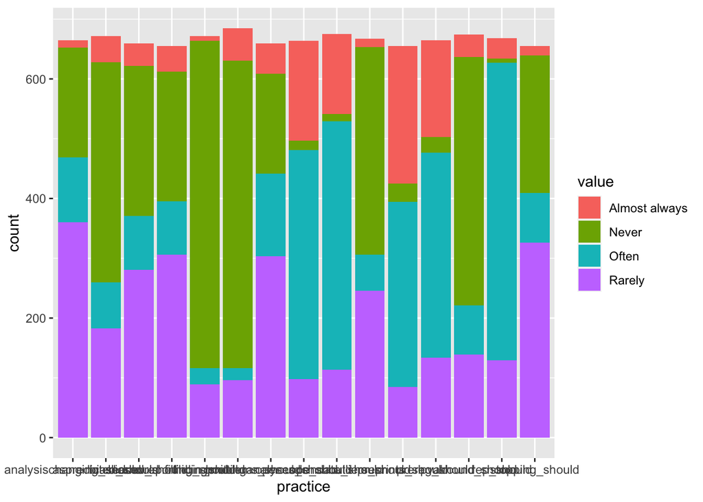

```r
shoulds <- QORP_quant %>% select_at(vars(ends_with("should"))) #e.g. aspredicted_should, opencode_should, pvalround_should

#Change it from numbers back to Never, Rarely, etc., which was created above with
# QORP$Q3.6 <- recode(QORP$Q3.6, "Never" = 1, "Rarely" = 2, "Often" = 3, "Almost always" = 4)

# https://stackoverflow.com/questions/47521920/recode-multiple-columns-using-dplyr
shoulds<- shoulds %>%  mutate_all( ~recode(.,`1`="Never", '2'="Rarely", '3'="Often", '4'="Almost always") )
#shoulds$aspredicted_should

#fewShoulds <- shoulds %>% select("opencode_should","opendata_should", "pvalround_should")
#longFewShoulds <- fewShoulds %>% pivot_longer(cols=c("opencode_should","opendata_should","pvalround_should"), names_to="practice")

longShoulds <- shoulds %>% pivot_longer(cols=everything(), names_to="practice")

# ggplot(mpg, aes(class)) + geom_bar(aes(fill = drv))

ggplot( drop_na(longShoulds), aes(practice)) +  geom_bar(aes(fill=value))
```

Figure 2. Stacked bar chart for support for QRPs

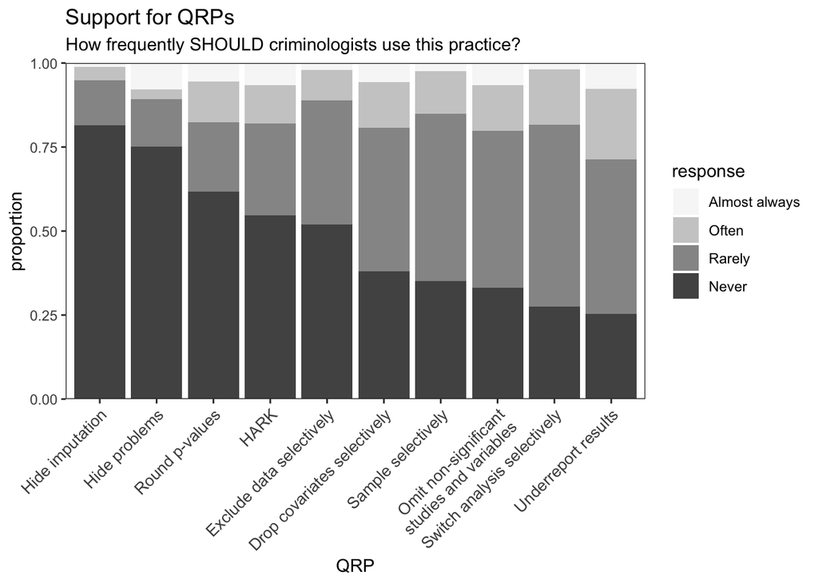

```r
QRPvarnames <- c("aspredicted_should","omittinganalyses_should","hidingproblems_should","fillingin_should","biasedreporting_should","stopping_should","biasedcov_should","pvalround_should","analysischanging_should","outliers_should")

QRPs <- shoulds %>% select( all_of(QRPvarnames) )


longQRPs <- QRPs %>% pivot_longer(cols=everything(), names_to="practice", values_to="response")

longQRPs <- longQRPs %>% mutate(
  practiceLongName = case_when(
    practice=="biasedreporting_should" ~ "Omit non-significant\nstudies and variables",
    practice=="aspredicted_should" ~ "HARK",
    practice=="biasedcov_should" ~ "Drop covariates selectively",
    practice=="stopping_should" ~ "Sample selectively",
    practice=="omittinganalyses_should" ~ "Underreport results",
    practice=="pvalround_should" ~ "Round p-values",
    practice=="analysischanging_should" ~ "Switch analysis selectively",
    practice=="outliers_should" ~ "Exclude data selectively",
    practice=="hidingproblems_should" ~ "Hide problems",
    practice=="fillingin_should" ~ "Hide imputation",
    TRUE ~ "ERROR! unknown practice"
  )
 )
longQRPs$practiceLongName <- as.factor(longQRPs$practiceLongName)

practiceOrderDesiredNeverAscending <- 1:10
practiceOrderDesiredNeverAscending <- c(4,5,7,3,2,1,8,6,9,10)

longQRPs$practiceLongName <- factor(longQRPs$practiceLongName,
                                    levels = levels(longQRPs$practiceLongName)[practiceOrderDesiredNeverAscending])

longQRPs$response <- as.factor(longQRPs$response)
longQRPs$response <- fct_relevel(longQRPs$response, "Almost always","Often","Rarely","Never")

#plot after dropping NAs

stackedQRPplot <- ggplot( drop_na(longQRPs), aes(practiceLongName,fill=response)) +
  geom_bar(position="fill") + #this is what changes it from counts to proportion
  xlab("QRP") + ylab("proportion") +
  theme_bw() + theme(panel.grid.major = element_blank(), panel.grid.minor = element_blank()) + #remove backgrund including grid lines
  #scale_fill_viridis_d(option = "magma", direction=-1) +
  scale_fill_brewer(palette = "Greys") + #https://ggplot2-book.org/scale-colour.html
  labs(title='Support for QRPs',
       subtitle='How frequently SHOULD criminologists use this practice?') +
  theme(axis.text.x = element_text(angle = 45, hjust = 1, size = 10)) + #, legend.position = "top")
  scale_y_continuous(limits = c(0,1), expand = expansion(mult = c(0, 0))) #get rid of whitespace on top and bottom of axis limits https://stackoverflow.com/questions/22945651/how-to-remove-space-between-axis-area-plot-in-ggplot2/52318834#52318834

show(stackedQRPplot)
```

```r
ggsave( file.path("figures","fig2_stackedGraphQRPsOnly.png"),
        width = 30, height = 20, units = "cm")
```

Figure 4 - Stacked bar graph of OSPs

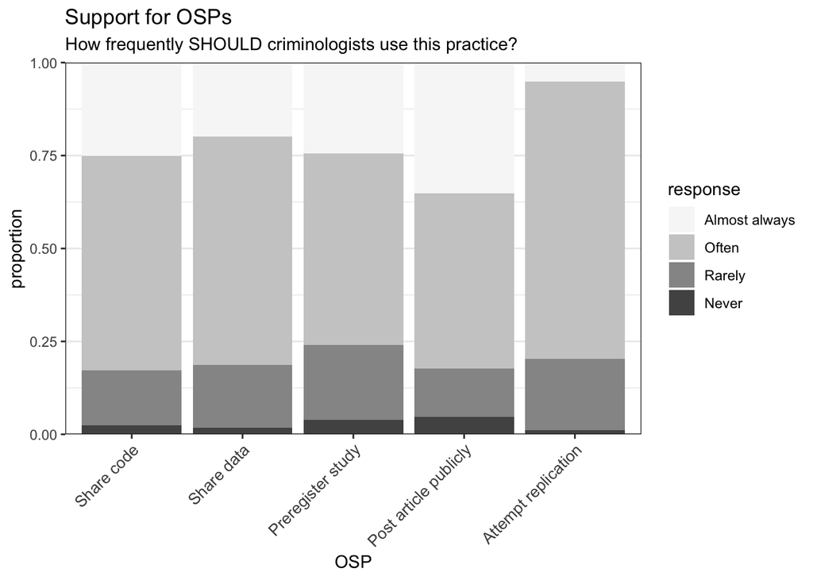

```r
OSPvarnames <- c("prereg_should","opendata_should","opencode_should","rep_should","preprints_should")

OSPs <- shoulds %>% select( all_of(OSPvarnames) )

longOSPs <- OSPs %>% pivot_longer(cols=everything(), names_to="practice", values_to="response")

####Create the standard longer OSP names
longOSPs <- longOSPs %>% mutate(
  practiceLongName = case_when(
    practice=="prereg_should" ~ "Preregister study",
    practice=="opendata_should" ~ "Share data",
    practice=="opencode_should" ~ "Share code",
    practice=="stopping_should" ~ "Sample selectively",
    practice=="rep_should" ~ "Attempt replication",
    practice=="preprints_should" ~ "Post article publicly",
    TRUE ~ "ERROR! unknown practice"
  )
 )

longOSPs$practiceLongName <- as.factor(longOSPs$practiceLongName)
#neworder <- c(3,8,)
#reorder

longOSPs$response <- as.factor(longOSPs$response)
longOSPs$response <- fct_relevel(longOSPs$response, "Almost always","Often","Rarely","Never")

#plot after dropping NAs

practiceOrderDesired <- c(4,5,3,2,1) #ordered to match Figure 2
longOSPs$practiceLongName <- factor(longOSPs$practiceLongName,
                                    levels = levels(longOSPs$practiceLongName)[practiceOrderDesired])

OSPsStackedBarChart<- ggplot( drop_na(longOSPs), aes( x=practiceLongName,fill=response )) +
  geom_bar(position="fill") + #this is what changes it from counts to proportion
  xlab("OSP") + ylab("proportion") + theme_bw() +
  scale_fill_brewer(palette = "Greys") +
  labs(title='Support for OSPs',
          subtitle ='How frequently SHOULD criminologists use this practice?') +
  theme(axis.text.x = element_text(angle = 45, hjust = 1, size = 10)) + #, legend.position = "top")
  scale_y_continuous(limits = c(0,1), expand = expansion(mult = c(0, 0)))

show(OSPsStackedBarChart)
```

```r
ggsave(file.path("figures","fig4_stackedGraphOSPs.png"), width = 30, height = 20, units = "cm")
```

Calculate the proportion of each response that is visualized in the above proportion plots - requested by Simine and not in manuscript

```r
tq<-drop_na(longQRPs) %>%
  group_by(practiceLongName, response) %>%
  summarise(n = n()) %>%
  mutate(proportion = n / sum(n)) %>%
  mutate(percentRounded = round(proportion*100,1)) %>%
  relocate(practiceLongName,response,percentRounded)
show(tq)
```

```
## # A tibble: 40 x 5
## # Groups:   practiceLongName [10]
##    practiceLongName response      percentRounded     n proportion
##    <fct>            <fct>                  <dbl> <int>      <dbl>
##  1 Hide imputation  Almost always            1.2     8     0.0119
##  2 Hide imputation  Often                    4      27     0.0402
##  3 Hide imputation  Rarely                  13.2    89     0.132
##  4 Hide imputation  Never                   81.5   548     0.815
##  5 Hide problems    Almost always            7.9    54     0.0788
##  6 Hide problems    Often                    2.9    20     0.0292
##  7 Hide problems    Rarely                  14      96     0.140
##  8 Hide problems    Never                   75.2   515     0.752
##  9 Round p-values   Almost always            5.5    37     0.0549
## 10 Round p-values   Often                   12.2    82     0.122
## # … with 30 more rows
```

```r
#https://sejdemyr.github.io/r-tutorials/basics/tables-in-r/
write.table(tq, file = "tables/QRPsupportTable.txt", sep = "\t", quote = FALSE, row.names = T)
```

Calculate the proportion of each response that is visualized in the above proportion plots - requested by Simine and not in manuscript

```r
# https://stackoverflow.com/questions/24576515/relative-frequencies-proportions-with-dplyr
to<- drop_na(longOSPs) %>%
  group_by(practiceLongName, response) %>%
  summarise(n = n()) %>%
  mutate(proportion = n / sum(n)) %>%
  mutate(percentRounded = round(proportion*100,1)) %>%
  relocate(practiceLongName,response,percentRounded)
show(to)
```

```
## # A tibble: 20 x 5
## # Groups:   practiceLongName [5]
##    practiceLongName      response      percentRounded     n proportion
##    <fct>                 <fct>                  <dbl> <int>      <dbl>
##  1 Share code            Almost always           25.2   167     0.252
##  2 Share code            Often                   57.7   383     0.577
##  3 Share code            Rarely                  14.8    98     0.148
##  4 Share code            Never                    2.4    16     0.0241
##  5 Share data            Almost always           19.9   134     0.199
##  6 Share data            Often                   61.5   415     0.615
##  7 Share data            Rarely                  16.9   114     0.169
##  8 Share data            Never                    1.8    12     0.0178
##  9 Preregister study     Almost always           24.4   162     0.244
## 10 Preregister study     Often                   51.6   343     0.516
## 11 Preregister study     Rarely                  20.2   134     0.202
## 12 Preregister study     Never                    3.9    26     0.0391
## 13 Post article publicly Almost always           35.1   230     0.351
## 14 Post article publicly Often                   47.2   309     0.472
## 15 Post article publicly Rarely                  13      85     0.130
## 16 Post article publicly Never                    4.7    31     0.0473
## 17 Attempt replication   Almost always            5.1    34     0.0509
## 18 Attempt replication   Often                   74.6   498     0.746
## 19 Attempt replication   Rarely                  19.3   129     0.193
## 20 Attempt replication   Never                    1       7     0.0105
```

```r
write.table(to, file = file.path("tables","OSPsupportTable.txt"), sep = "\t", quote = FALSE, row.names = T)
```

Figure - QRP perceived use only - Quant researchers - not in manuscript

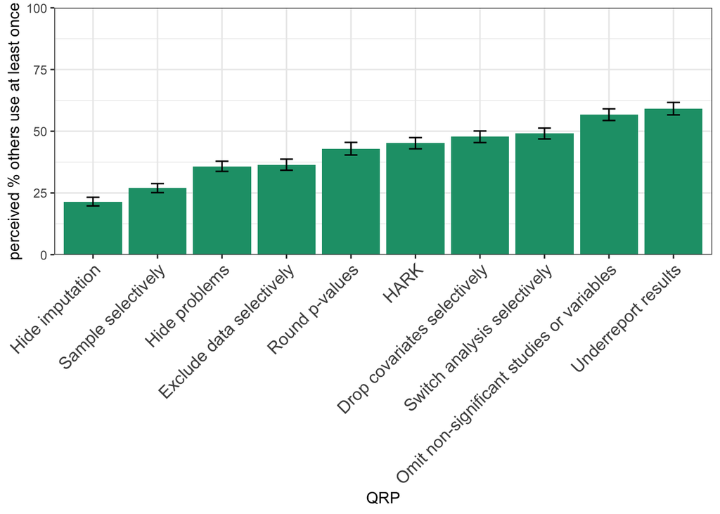

```r
#Creates figure plotting quant. criminologists' perceived prevalence (people who use at least once)

##Estimates of others
###Using a T-test to get confidence intervals, and hope that is okay, but it might violate some assumptions

others <-
QORP_quant %>%
select_at(vars(ends_with("others"))) %>%
map_df(~ broom::tidy(t.test(.)), .id = 'var')

others <- mutate(others, sorter = c(8,4,9,10,NA,NA,NA,NA,NA,1,3,5,7,2,6))
others <- arrange(others, sorter)
others <- na.omit(others)
others <- mutate(others, type = "others")
others <- select(others, -p.value, -statistic, -parameter, -method, -alternative)
others <- dplyr::rename(others, mean=estimate, ymin = conf.high, ymax = conf.low)

###Changes the name of the main variables

####Prepares the main QRP variable of interest by removing the parts that identify the statistic used (this is captured in the type variable instead)

others$var <- sub("_others", "", others$var)

####Changes the main QRP variable of interest to the standard QRP names

others$var <- sub("biasedreporting", "Omit non-significant studies or variables", others$var)
others$var <- sub("stopping", "Sample selectively", others$var)
others$var <- sub("biasedcov", "Drop covariates selectively", others$var)
others$var <- sub("omittinganalyses", "Underreport results", others$var)
others$var <- sub("pvalround", "Round p-values", others$var)
others$var <- sub("analysischanging", "Switch analysis selectively", others$var)
others$var <- sub("outliers", "Exclude data selectively", others$var)
others$var <- sub("aspredicted", "HARK", others$var)
others$var <- sub("hidingproblems", "Hide problems", others$var)
others$var <- sub("fillingin", "Hide imputation", others$var)

##Creates Figure

others_QRP <-
  ggplot(others, aes(fill = type, y = mean, x = reorder(var, mean), show.legend = FALSE)) +
  ylab("perceived % others use at least once") +
  xlab("QRP") + theme_bw() +
  scale_fill_brewer(palette = "Dark2", guide = FALSE) +
  theme(axis.text.x = element_text(angle = 45, hjust = 1, size = 12)) +
  geom_bar(position="dodge", stat="identity") +
  geom_errorbar( aes(ymin = ymin, ymax = ymax), position=position_dodge(.9), colour="black", width = .2) +
  scale_y_continuous(limits = c(0,100), expand = expansion(mult = c(0, 0))) #https://stackoverflow.com/questions/22945651/how-to-remove-space-between-axis-area-plot-in-ggplot2/52318834#52318834

show(others_QRP)
```

```r
ggsave( file.path("figures","fig_perceived_quant.png"), width = 30, height = 20, units = "cm")
```

Figure - QRP perceived use only - Quant researchers - Boostrapped CIs - not in manuscript

Same as above but with bootstrapped CIs # Frank E Harrell Jr, with contributions from Charles Dupont and many others. (2020). Hmisc: Harrell Miscellaneous. R package version 4.4-1. https://CRAN.R-project.org/package=Hmisc

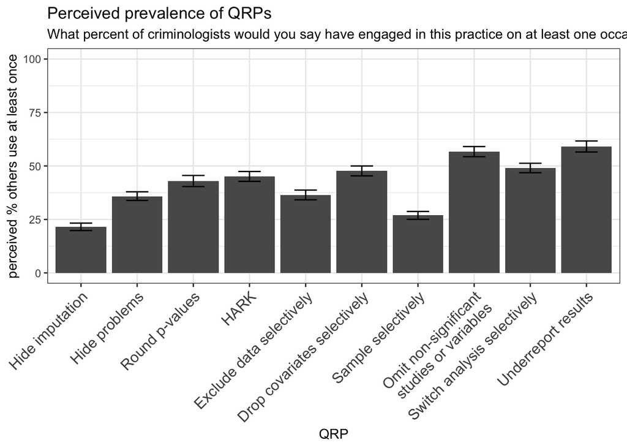

```r
others <- QORP_quant %>% select_at(vars(ends_with("others")))

QRPvarnames <- c("aspredicted_others","omittinganalyses_others","hidingproblems_others","fillingin_others","biasedreporting_others","stopping_others","biasedcov_others","pvalround_others","analysischanging_others","outliers_others")

QRPprevalence <- others %>% select( all_of(QRPvarnames) )

#get into long instead of wide format, so ggplot and tidyverse can do all the magic it does
longQRPprevalence <- QRPprevalence %>% pivot_longer(cols=everything(), names_to="practice", values_to="response")

longQRPprevalence <- longQRPprevalence %>% mutate(
  practiceLongName = case_when(
    practice=="biasedreporting_others" ~ "Omit non-significant\nstudies or variables",
    practice=="aspredicted_others" ~ "HARK",
    practice=="biasedcov_others" ~ "Drop covariates selectively",
    practice=="stopping_others" ~ "Sample selectively",
    practice=="omittinganalyses_others" ~ "Underreport results",
    practice=="pvalround_others" ~ "Round p-values",
    practice=="analysischanging_others" ~ "Switch analysis selectively",
    practice=="outliers_others" ~ "Exclude data selectively",
    practice=="hidingproblems_others" ~ "Hide problems",
    practice=="fillingin_others" ~ "Hide imputation",
    TRUE ~ "ERROR! unknown practice"
  )
 )
longQRPprevalence$practiceLongName <- as.factor(longQRPprevalence$practiceLongName)
#levels(longQRPprevalence$practiceLongName)

practiceOrderDesiredNeverAscending <- c(4,5,7,3,2,1,8,6,9,10)
longQRPprevalence$practiceLongName <- factor(longQRPprevalence$practiceLongName,
                                    levels = levels(longQRPprevalence$practiceLongName)[practiceOrderDesiredNeverAscending])

fig1_alt_other<-
  ggplot( drop_na(longQRPprevalence), aes(x = practiceLongName, y = response) ) +
        stat_summary(fun = mean, geom = "bar") + theme_bw() +
        stat_summary(fun.data = mean_cl_boot, fun.args=(conf.int=0.95), geom = "errorbar", width = 0.4) +
      xlab("QRP") + ylab("perceived % others use at least once") + ylim(0,100) +
      scale_fill_brewer(palette = "YlGn") + #https://ggplot2-book.org/scale-colour.html
      labs(title='Perceived prevalence of QRPs',
        subtitle='What percent of criminologists would you say have engaged in this practice on at least one occasion?') +
      theme(axis.text.x = element_text(angle = 45, hjust = 1, size = 12))

show(fig1_alt_other)
```

```r
ggsave(file.path("figures","fig_perceived_quant_bootstrapped.png"), width = 30, height = 20, units = "cm")
```

Figure - OSP perceived use only - Quant researchers - not in manuscript

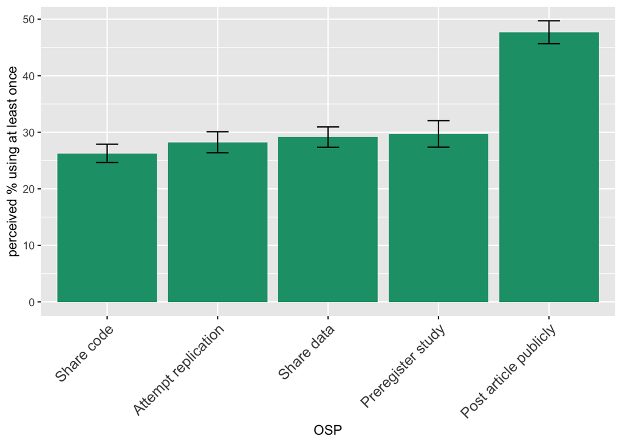

```r
#Estimates of others
##Using a T-test to get confidence intervals, and hope that is okay, but it might violate some assumptions

others <-
QORP_quant %>%
select_at(vars(ends_with("others"))) %>%
map_df(~ broom::tidy(t.test(.)), .id = 'var')

others <- mutate(others, sorter = c(NA,NA,NA,NA,1,2,3,4,5,NA,NA,NA,NA,NA,NA))
others <- arrange(others, sorter)
others <- na.omit(others)
others <- mutate(others, type = "others")
others <- select(others, -p.value, -statistic, -parameter, -method, -alternative)
others <- dplyr::rename(others, mean=estimate, ymin = conf.high, ymax = conf.low)

##Changes the name of the main variables

###Prepares the main QRP variable of interest by removing the parts that identify the statistic used (this is captured in the type variable instead)

others$var <- sub("_others", "", others$var)

####Changes the main QRP variable of interest to the standard QRP names

others$var <- sub("prereg", "Preregister study", others$var)
others$var <- sub("opendata", "Share data", others$var)
others$var <- sub("opencode", "Share code", others$var)
others$var <- sub("rep", "Attempt replication", others$var)
others$var <- sub("pAttempt replicationrints", "Post article publicly", others$var)

#Creates Figure

others_OSP <-
  ggplot(others, aes(fill = type, y = mean, x = reorder(var, mean))) +
  ylab("perceived % using at least once") +
  xlab("OSP") +
  scale_fill_brewer(palette = "Dark2", guide = FALSE) +
  theme( axis.text.x = element_text(angle = 45, hjust = 1, size = 12), legend.position = "top") +
  geom_bar(position="dodge", stat="identity") +
  geom_errorbar( aes(ymin = ymin, ymax = ymax), position=position_dodge(.9), colour="black", width = .2)

show(others_OSP)
```

```r
ggsave(file.path("figures","fig_perceived_OSP_quant.png"), width = 30, height = 20, units = "cm")
```

Figure - OSP perceived use only - Quant researchers - bootstrapped CIs - not in manuscript

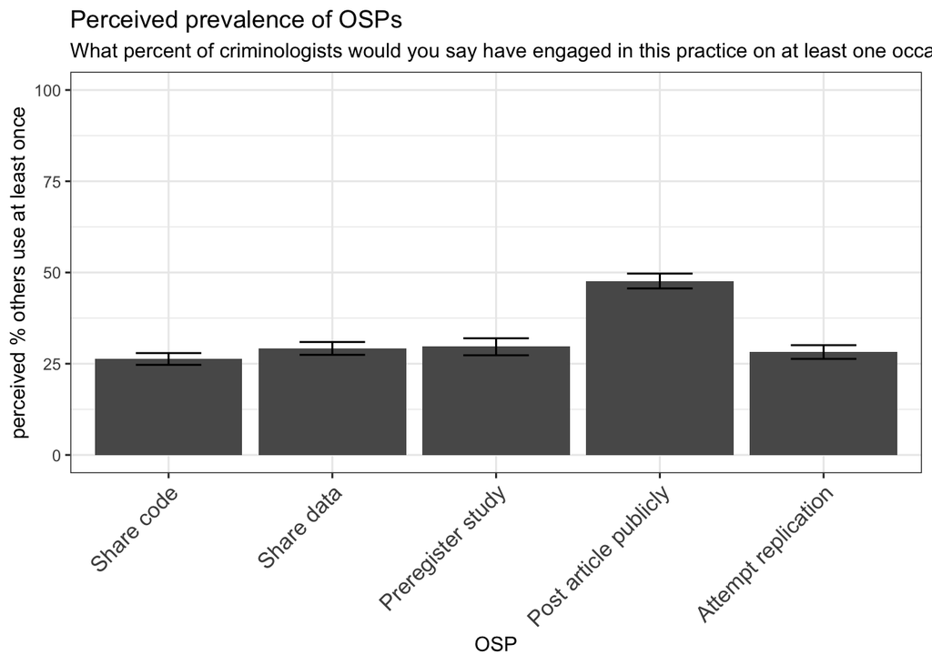

```r
others <- QORP_quant %>% select_at(vars(ends_with("others")))

OSPvarnames <- c("prereg_others","opendata_others","opencode_others","rep_others","preprints_others")

OSPprevalence <- others %>% select( all_of(OSPvarnames) )

#get into long instead of wide format, so ggplot and tidyverse can do all the magic it does
longOSPprevalence <- OSPprevalence %>% pivot_longer(cols=everything(), names_to="practice", values_to="response")

longOSPprevalence <- longOSPprevalence %>% mutate(
  practiceLongName = case_when(
    practice=="prereg_others" ~ "Preregister study",
    practice=="opendata_others" ~ "Share data",
    practice=="opencode_others" ~ "Share code",
    practice=="stopping_others" ~ "Sample selectively",
    practice=="rep_others" ~ "Attempt replication",
    practice=="preprints_others" ~ "Post article publicly",
    TRUE ~ "ERROR! unknown practice"
  )
 )
longOSPprevalence$practiceLongName <- as.factor(longOSPprevalence$practiceLongName)

practiceOrderDesired <- c(4,2,5,1,3) #ordered approximately by the sum of often and almost always
longOSPprevalence$practiceLongName <- factor(longOSPprevalence$practiceLongName,
                                    levels = levels(longOSPprevalence$practiceLongName)[practiceOrderDesiredNeverAscending])

fig2_alt_other<-
  ggplot( drop_na(longOSPprevalence), aes(x = practiceLongName, y = response) ) +
        stat_summary(fun = mean, geom = "bar") + theme_bw() +
        stat_summary(fun.data = mean_cl_boot, fun.args=(conf.int=0.95), geom = "errorbar", width = 0.4) +
      xlab("OSP") + ylab("perceived % others use at least once") + ylim(0,100) +
      scale_fill_brewer(palette = "YlGn") + #https://ggplot2-book.org/scale-colour.html
      labs(title='Perceived prevalence of OSPs',
        subtitle='What percent of criminologists would you say have engaged in this practice on at least one occasion?') +
      theme(axis.text.x = element_text(angle = 45, hjust = 1, size = 12))

show(fig2_alt_other)
```

```r
ggsave(file.path("figures","fig_perceived_OSP_quant_bootstrapped.png"), width = 30, height = 20, units = "cm")
```

This part now turns to plotting the actual data points with raincloud or similar. First plot a histogram to get a feel for the data.

QRPs

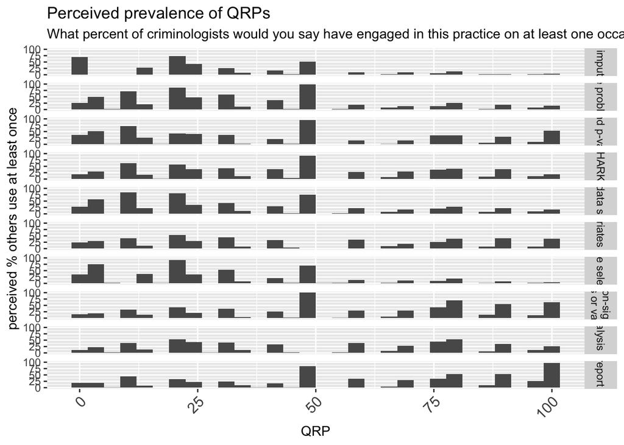

```r
ggplot( drop_na(longQRPprevalence), aes(x = response) ) +
      geom_histogram()+ facet_grid(practiceLongName~.) +
      xlab("QRP") + ylab("perceived % others use at least once") + ylim(0,100) +
      scale_fill_brewer(palette = "YlGn") + #https://ggplot2-book.org/scale-colour.html
      labs(title='Perceived prevalence of QRPs',
        subtitle='What percent of criminologists would you say have engaged in this practice on at least one occasion?') +
      theme(axis.text.x = element_text(angle = 45, hjust = 1, size = 12))
```

Figure 1 - Distributions of perceived prevalence for QRPs - quant researchers only

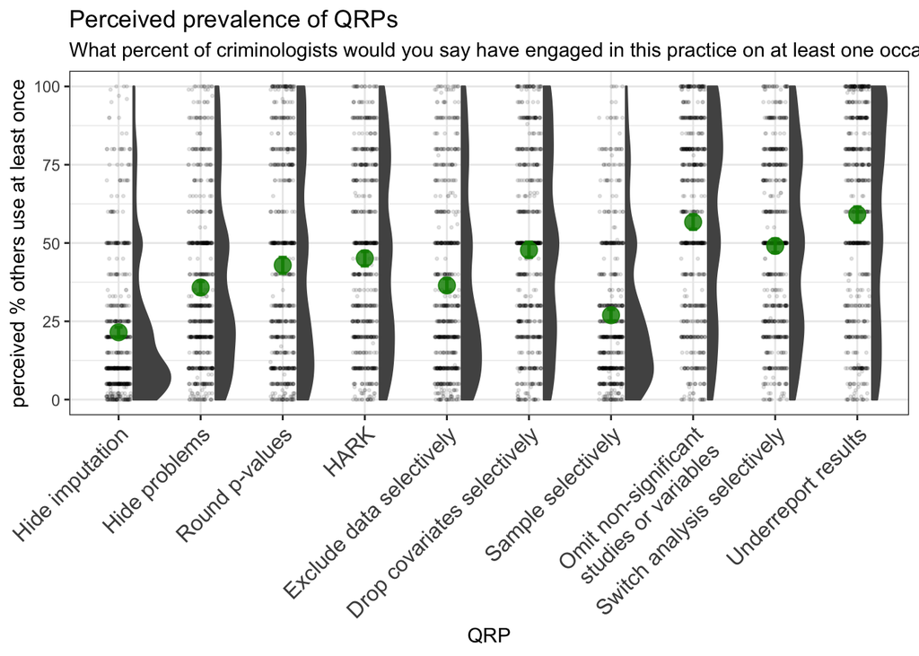

```r
#https://datavizpyr.com/rain-cloud-plots-using-half-violin-plot-with-jittered-data-points-in-r/
#Load half violin plot: geom_flat_violin()
source("https://raw.githubusercontent.com/datavizpyr/data/master/half_flat_violinplot.R")

#Save tibble so that separate file can plot all 5 datasets on the same graph
saveRDS(longQRPprevalence, file = "longQRPs.rds")

QRPprevCloud <-  ggplot( drop_na(longQRPprevalence), aes(x = practiceLongName, y = response) ) +
      theme_bw() +
      geom_flat_violin(fill="gray32",color="gray32", position = position_nudge(x = .18, y = 0)) +
      geom_jitter(alpha=0.1, size=.5, width=0.15, height=0) +
      stat_summary(fun = mean, geom = "point", color='green4', size=4, alpha=0.82) +
      stat_summary(fun.data = mean_cl_boot, fun.args=(conf.int=0.95), geom="errorbar", size=.9, width=0.1, color='green4', alpha=0.82) +
      #geom_jitter(width=0.2, size=.2, alpha=0.1)+
      xlab("QRP") + ylab("perceived % others use at least once") + ylim(0,100) +
      scale_fill_brewer(palette = "YlGn") + #https://ggplot2-book.org/scale-colour.html
      labs(title='Perceived prevalence of QRPs',
        subtitle='What percent of criminologists would you say have engaged in this practice on at least one occasion?') +
      theme(axis.text.x = element_text(angle = 45, hjust = 1, size = 12))

show(QRPprevCloud)
```

```r
ggsave( file.path("figures","Fig1_QRPperceivedPrevalenceCloud.png"), width = 30, height = 20, units = "cm")
```

OSPs

Now plot the actual data points with raincloud or similar. First plot a histogram to get a feel for the data.

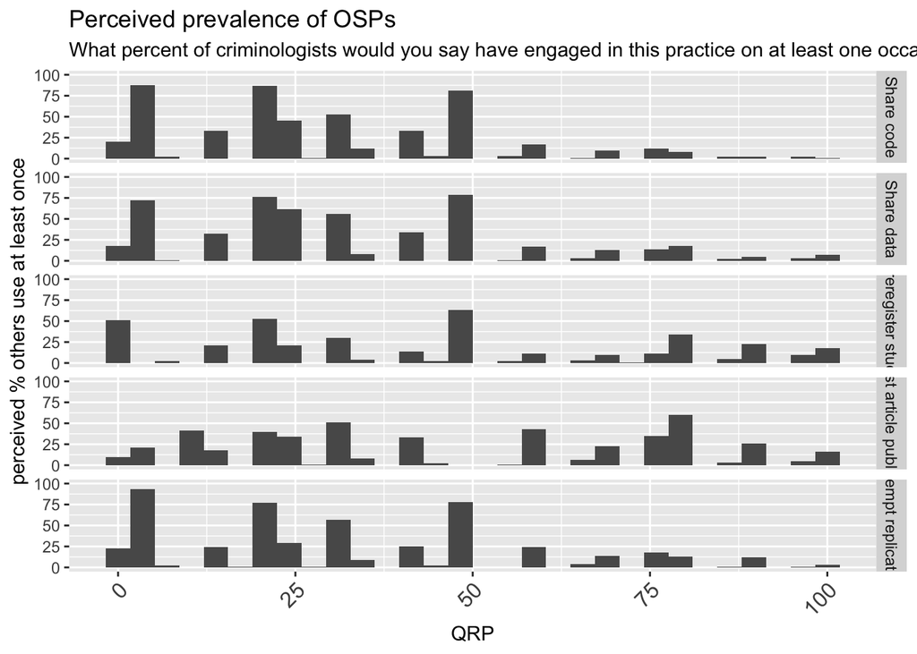

```r
ggplot( drop_na(longOSPprevalence), aes(x = response) ) +
      geom_histogram()+ facet_grid(practiceLongName~.) +
      xlab("QRP") + ylab("perceived % others use at least once") + ylim(0,100) +
      scale_fill_brewer(palette = "YlGn") + #https://ggplot2-book.org/scale-colour.html
      labs(title='Perceived prevalence of OSPs',
        subtitle='What percent of criminologists would you say have engaged in this practice on at least one occasion?') +
      theme(axis.text.x = element_text(angle = 45, hjust = 1, size = 12))
```

Figure 3 - Perceived prevalance of OSPs - quant only

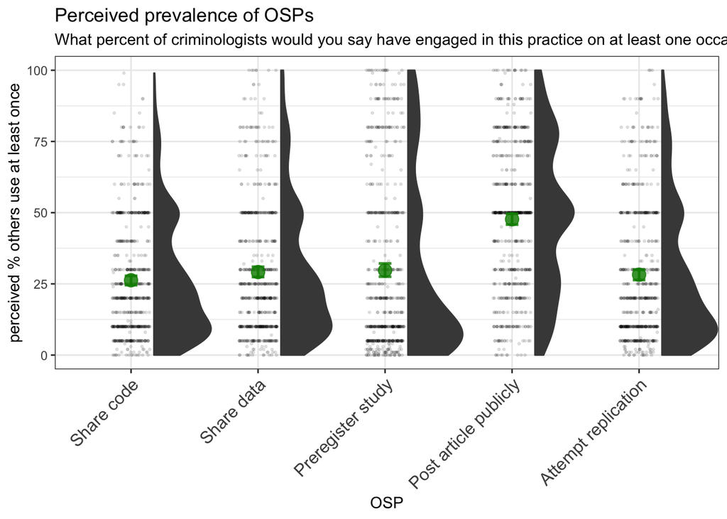

```r
#https://datavizpyr.com/rain-cloud-plots-using-half-violin-plot-with-jittered-data-points-in-r/
#Load half violin plot: geom_flat_violin()
#source("https://raw.githubusercontent.com/datavizpyr/data/master/half_flat_violinplot.R")

OSPprevCloud <-  ggplot( drop_na(longOSPprevalence), aes(x = practiceLongName, y = response) ) +
      theme_bw() +
      geom_jitter(alpha=0.1, size=.5, width=0.15, height=0) +
      stat_summary(fun = mean, geom = "point", color='green4', size=4, alpha=0.82) +
      stat_summary(fun.data = mean_cl_boot, fun.args=(conf.int=0.95), geom="errorbar", size=.9, width=0.1, color='green4', alpha=0.82) +
      geom_flat_violin(fill="gray28",color="gray28", position = position_nudge(x = .18, y = 0)) +
      #geom_jitter(width=0.2, size=.2, alpha=0.1)+
      #geom_point(position="dodge") + #dodge does not work
      xlab("OSP") + ylab("perceived % others use at least once") + ylim(0,100) +
      labs(title='Perceived prevalence of OSPs',
        subtitle='What percent of criminologists would you say have engaged in this practice on at least one occasion?') +
      theme(axis.text.x = element_text(angle = 45, hjust = 1, size = 12))

show(OSPprevCloud)
```

```r
ggsave( file.path("figures","OSPperceivedPrevalenceCloud.png"), width = 30, height = 20, units = "cm")
```